# From Classrooms to Impact

Turning Academic Projects into Real-World Solutions

SpeedyKom Team

2026-02-21

## Scan to Join

**Scan this QR code to access the presentation:**

[figure not shown]

## Welcome

### Turning Academic Assignments into Real Solutions

**Saturday, February 21, 2026**  
**9:00 AM — 11:00 AM CET**

## The Reality Check

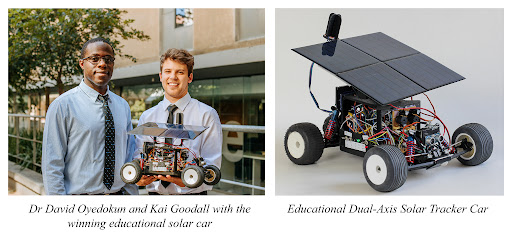

Students presenting their solar car project

## The Reality Check

Universities produce thousands of projects every year:

- Mobile apps
- AI diagnostic tools
- E-learning platforms
- Smart agriculture systems
- Fintech solutions

**…but only a small fraction ever see real-world use.**

## Why Do Projects Fail?

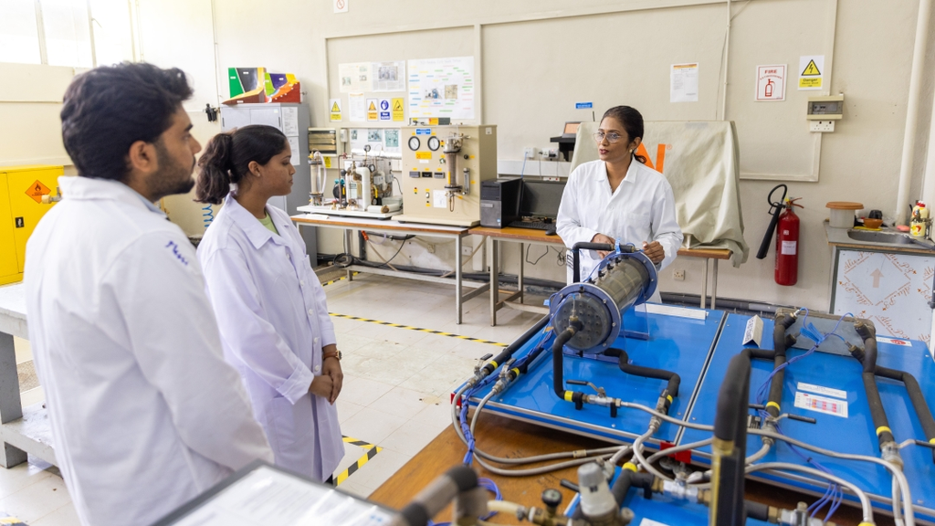

Students in engineering lab

## Why Do Projects Fail?

**Academic Mindset:**

- Built for grades, not users
- Ignore existing infrastructure
- Assume perfect conditions
- One-time build, no maintenance

**Reality:**

- Users have real needs
- Systems already exist
- Connectivity is limited
- Sustainability matters

## Common Projects That Fail

1. **“Uber for X” Apps** — Ignore low smartphone penetration
2. **Standalone E-Learning** — Universities already use Moodle
3. **AI Diagnostic Tools** — No validation with real medical data
4. **IoT Agriculture Sensors** — Farmers can’t afford hardware
5. **Blockchain Voting** — Trust issues are social, not technical
6. **“Better than M-Pesa” Apps** — Ignore regulatory requirements

## What Students Need

**Technical Skills:**

- Interoperability
- Open standards
- Secure-by-design architecture
- Offline-first development
- AI integration

## What Students Need

**Strategic Thinking:**

- Problem-first approach
- Understanding stakeholders
- Sustainability planning
- Regulatory awareness
- Impact measurement

## Critical Questions

**Important**

Before you write a single line of code:

- Who will maintain this in 5 years?
- How does it connect to existing systems?
- What happens when the internet is down?
- Why would someone pay for this?

## About SpeedyKom

**Digital Infrastructure for Future Societies**

We help governments and development actors design and build digital systems that deliver lasting public impact.

**Headquarters:** Germany  
**Focus:** Africa & Europe  
**Partners:** EU, GIZ, African Union, UNHCR, FAO

## What SpeedyKom Does

**Core Expertise:**

- Public Sector Digital Transformation
- Digital Health Systems
- Interoperability & Integration
- Open Standards & Open Source

## What SpeedyKom Does

**Technologies:**

- AI & Machine Learning
- Secure-by-Design Software
- Agile Methods
- Cloud & Edge Computing

## Real Projects, Real Impact

- **Malawi National eRegister** — Digital health records
- **Digital One Health Platform** — Disease surveillance
- **Beninnovation** — Digital public services
- **EPEPI Electrification Portal** — Energy access planning
- **Zambia ARPA Dashboards** — Climate resilience

## Our Philosophy

**Important**

**“Digital systems should strengthen public institutions and advance development outcomes, not just digitize workflows.”**

Technology that is secure, scalable, context-rooted, and sustainable.

## 5,500 Years of Partnership

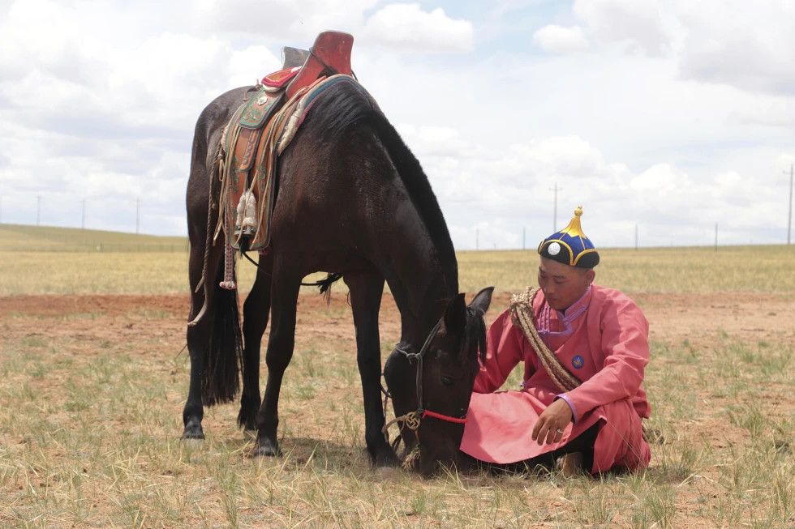

Mongolian pastoralist with horse

## 5,500 Years of Partnership

**The Beginning (~3500 BCE):**

- **Where:** Kazakhstan (Botai culture)
- **What:** First domestication of horses

**The Partnership:** - Humans bred horses for strength and speed - A symbiotic relationship developed

## Horses Enabled Civilization

**For Millennia:**

- **Agriculture** — plowing fields, transporting harvests
- **Commerce** — trade routes, carrying goods
- **Warfare** — cavalry charges, logistics
- **Communication** — messengers, postal systems

## The Horse-Drawn Era

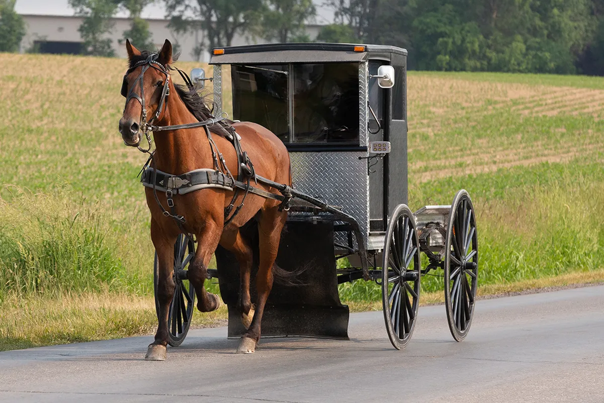

Horse and buggy carriage

## The Horse-Drawn Era

**Peak of Horse Power:**

- Every city had thousands of horses
- Stables on every corner
- Horse-drawn trams and buses
- Individual horse ownership common

**Even in WWII:** Horses moved supplies and artillery when trucks failed.

## The Machine Age Arrives

**The Steam Engine (1800s):**

- First machines matching horse power
- Trains moved faster than any horse
- But still needed human operators

**The Internal Combustion Engine (1885+):**

- Benz creates first practical automobile
- Ford’s Model T (1908) makes cars affordable

## The Collapse

**Timeline:**

- **1900:** 21 million horses in the US
- **1920:** Cars outnumber horses in cities
- **1940:** Horses rare in developed world
- **1960:** Horses mainly for recreation

**The Math:**

- 5,500 years of partnership
- Gone in 50 years

**Horses didn’t become extinct.**

**They became obsolete for work.**

## From Work to Recreation

[figure not shown]

Electric horseless carriage for events

## The Pattern Emerges

1. **Tool as Amplifier** — Horse extends muscle power
2. **Tool as Partner** — Human + animal capability
3. **Machine as Amplifier** — Car extends reach faster
4. **Machine as Replacement** — No feeding, rest, training needed

## From Mechanical to Cognitive

**Industrial Revolution:**

- Replaced physical labor
- Machines stronger than muscles
- But still needed human operators

**AI Revolution:**

- Replacing cognitive labor
- AI faster at pattern recognition
- **Can make decisions autonomously**

## The Final Transition

[figure not shown]

Waymo autonomous taxi

## The Final Transition

**Where We Are Now:**

- **Tesla Autopilot** — 500,000+ cars with self-driving
- **Waymo** — Robotaxis in San Francisco, Phoenix
- **Self-driving trucks** — Testing on highways globally

**Timeline:**

- 2015: First autopilot features
- 2020: Full self-driving beta
- 2024: Robotaxis commercially operating

## Human Drivers: The New Horses

**Warning**

**The “driver” — human decision-making behind the wheel — is being eliminated.**

**The Pattern Completes:**

- Horse (biological amplifier) →
- Car (mechanical amplifier) →
- AI Car (cognitive replacement)

## Beyond Driving

[figure not shown]

## The Robot Revolution

**Physical Robots:**

- Boston Dynamics Atlas — Humanoid robots
- Tesla Optimus — Factory work
- Warehouse robots — Amazon fulfillment
- Surgical robots — Da Vinci operations

## The Robot Revolution

**Cognitive AI:**

- ChatGPT/Claude — Writing, coding, analysis
- Computer vision — Disease diagnosis
- Trading algorithms — Financial decisions
- Content generation — Art, music, video

## The New Reality

**Important**

**Anything that requires a brain to make decisions can be replaced by AI.**

**Each transition accelerates:**

- Horses: 5,500 years
- Cars: 50 years
- AI: **Maybe 15-20 years**

## What AI Can Replace in Africa

**Transportation:**

- Boda-boda route optimization
- Truck drivers
- Traffic management

## What AI Can Replace in Africa

**Agriculture:**

- Crop disease diagnosis
- Irrigation decisions
- Market price prediction

## What AI Can Replace in Africa

**Healthcare:**

- Initial patient triage
- Lab test analysis
- Disease outbreak detection

## What AI Can Replace in Africa

**Finance & Government:**

- Credit scoring and fraud detection
- Tax auditing
- Document verification
- Claims processing

## What AI Cannot Replace

The human elements that remain essential:

- Complex ethical judgments
- True creativity and innovation
- Human empathy and context
- Cross-domain strategic thinking
- Accountability

## The African Context

**Why It Might Be Different:**

- Lower labor costs
- Infrastructure challenges
- Regulatory gaps
- Cultural preferences

**Why It Will Still Happen:**

- Cost advantages of AI
- Global technology diffusion
- Young population embracing tech
- Leapfrogging opportunity

## Bridging the Gap

**How SpeedyKom Can Help:**

- Real-world project examples
- Technical mentorship
- Industry best practices
- Professional network
- Career pathways in ICT4D

## What SpeedyKom Looks For

- Problem-first thinking
- Context awareness
- Sustainability mindset
- Collaboration skills
- Impact orientation

## Academic vs. Real-World

| Failed Academic | SpeedyKom Approach |
| --- | --- |
| Build first, find users | Start with partnerships |
| Ignore existing systems | Interoperability first |
| Assume connectivity | Offline-first design |
| One-time build | Long-term maintenance |
| Tech-focused | Problem-first focus |

## Your Path Forward

1. **Start with the problem** — What pain point? For whom?
2. **Understand the ecosystem** — What exists? Who are stakeholders?
3. **Design for reality** — Offline-first, integration, sustainability
4. **Think long-term** — Who maintains? How does it scale?

## What We Offer

**Tip**

This session is just the beginning.

- Exposure to international projects
- Clarity on market-ready solutions
- Network with industry professionals
- Mentorship on your projects
- Career pathways in tech-for-impact

## SpeedyKom’s Vision

Digital infrastructure that strengthens public institutions and advances sustainable development across Africa.

**Our Values:**

- Impact over innovation
- Partnership over extraction
- Sustainability over speed

## Let’s Connect

**Important**

We are looking for the next generation of impact-driven technologists.

**Questions to ask yourself:**

- What problem am I passionate about?
- How can technology amplify human impact?
- Am I ready to think beyond grades?

## Thank You

### Questions & Discussion

**SpeedyKom**

Connecting the Future  
Digital Infrastructure for Development

[www.speedykom.de](https://speedykom.de)

## Connect With Us

**Scan this QR code to connect with us via LinkedIn**

[figure not shown]